# Figure 5 and supplementary figure 5

Author

Niccolò Arecco, Ivano Mocavini and Enrique Blanco

Last code execution: 2023 September 08, Friday @ 19:09:51.

# 1 Intro

ChIP-seq analysis.

# 2 Set Up

General info.

## 2.1 Packages

```r
library(dplyr, warn.conflicts = F, quietly = T)
library(readr)
library(stringr)
library(tidyr)
library(tibble)
library(ggplot2)
library(ggh4x)
library(ggrastr)
library(DT)
```

## 2.2 Functions

Define a plot style.

```r
theme_classic(base_family = 'Arial', base_size = 6) +
  theme(axis.text = element_text(colour = 'black'),
        axis.ticks.length = unit(1, 'mm'),
        axis.ticks = element_line(linewidth = 0.1),
        axis.line = element_line(linewidth = 0.1),
        axis.title = element_text(size = 5),
        panel.grid.major = element_line(linewidth = 0.2, colour = 'gray84'),
        strip.text = element_text(size = 10),
        strip.background = element_blank(),
        legend.title = element_blank(),
        legend.key.size = unit(1, 'mm'),
        legend.position = c(0.21, 0.92),
        legend.box.background = element_blank(),
        legend.margin = margin(t = -1, b = 1, unit = 'mm'),
        plot.background = element_blank(),
        panel.background = element_blank()) -> scatter_th

theme_classic(base_family = 'Arial', base_size = 6) +
  theme(axis.text = element_text(colour = 'black'),
        axis.text.x = element_text(angle = 45, hjust = 1, margin = margin(t = -0.4, unit = 'mm') ),
        axis.title.x = element_blank(),
        axis.ticks.length.y = unit(1, 'mm'),
        axis.ticks = element_line(linewidth = 0.1),
        axis.ticks.x = element_blank(),
        axis.line = element_line(linewidth = 0.1),
        axis.title = element_text(size = 5),
        panel.grid.major.y = element_line(linewidth = 0.2, colour = 'gray84'),
        panel.background = element_blank(),
        panel.spacing = unit(3, 'mm'),
        strip.text = element_text(size = 5),
        strip.background = element_rect(linewidth = 0.1),
        plot.background = element_blank() ) -> boxplot_th

theme_classic(base_family = 'Arial', base_size = 6) +
  theme(axis.text = element_text(colour = 'black'),
        axis.text.x = element_text(margin = margin(t = -0.4, unit = 'mm') ),
        axis.ticks.length.y = unit(1, 'mm'),
        axis.ticks = element_line(linewidth = 0.1),
        axis.ticks.x = element_blank(),
        axis.line = element_line(linewidth = 0.1),
        axis.title = element_text(size = 5),
        panel.grid.major = element_line(linewidth = 0.2, colour = 'gray84'),
        panel.background = element_blank(),
        panel.spacing = unit(3, 'mm'),
        legend.position = c(0.93, 0.87),
        legend.key.size = unit(1, 'mm'),
        legend.title = element_blank(),
        legend.box.background = element_blank(),
        legend.margin = margin(t = -1, b = 1, unit = 'mm'),
        strip.text = element_text(size = 5),
        strip.background = element_rect(linewidth = 0.1),
        plot.background = element_blank() ) -> profile_th
```

Helper functions for the analysis.

Scale from zero to 1.

```r
scale01 <- function(x){
  z <- ( x - min(x) ) / ( max(x) - min(x) )
  return(z)
}
```

Function import GENEprofile files from SeqCode

```r
# read "GENEprofile" file types from SeqCode
read_prfl <- function(path_dir, txt_name, epitope, geneset_type, sample_name) {
  df_in <- read_delim(file = file.path(path_dir, txt_name),
                      delim = '\t', show_col_types = FALSE, col_names = F ) |>
    setNames( c("MetaPosition", paste0(epitope, "_signal") ) ) |>
    mutate(type = geneset_type, Sample = sample_name )
  return(df_in)
}
```

## 2.3 Directories & File Paths

Here I organise all the file and directories- paths I need to run the analysis and define where to save the processed tables and figures.

```r
oneDrive_Dir <- file.path("~/OneDrive - CRG - Centre de Regulacio Genomica/Suz12_AS_project")
code_dir_fig <- file.path(oneDrive_Dir, "_Code/Fig5")
tbl_dir_fig5 <- file.path(code_dir_fig, "tables")
pdf_dir_fig5 <- file.path(code_dir_fig, "pdfs")

if (!dir.exists(pdf_dir_fig5)) { dir.create(pdf_dir_fig5, recursive = T) }
if (!dir.exists(tbl_dir_fig5)) { dir.create(tbl_dir_fig5, recursive = T) }
```

Path to DropBox folders where Enrique releases the documents.

```r
dropbox_dir <- file.path('~/Dropbox (CRG ADV)/54_Suz12AS')

round17_meta_dir <- file.path(dropbox_dir, 'ROUND17_Figure3/01_files_for_boxplotofmetaplots')
round17_scatter_dir <- file.path(dropbox_dir, 'ROUND17_Figure3/02_files_for_scattersboxplots')
stopifnot(dir.exists(round17_meta_dir))
stopifnot(dir.exists(round17_scatter_dir))

round21_meta_dir <- file.path(dropbox_dir, 'ROUND21_PcGSubUnitChIPseq/METAPLOTS/GENEPLOTS')
stopifnot(dir.exists(round21_meta_dir))
```

List all bed files to be used for the metagene profiles

```r
bed_paths <- list.files(round17_meta_dir, recursive = T, pattern = "*.bed$")
```

Path where the data to plot meta genes profiles for H3K27me3 are stored.

```r
CGI_Dir <- file.path(oneDrive_Dir, '11_ChIP/Processed_data/Metaplots_CGI')
stopifnot(dir.exists(CGI_Dir))
```

List the path the `deeptools3` `compureMatrix` output.

```r
mat_dir <- file.path("~/mnt/narecco/projects/07_Suz12AS/data/matrix/Amniota_Testes")
stopifnot(dir.exists(CGI_Dir))
```

# 3 Main Figure Panels

## 3.1 Spike-in normalised H3K27me3 signal in 2.5kb genomic bins

Import all 2.5 kb bins of H3K27me3.

```r
all_bins25kb_K27me3 <- read_delim(file = file.path(round17_scatter_dir, 'H3K27me3_R3all_bins_2.5Kb_yes.txt'),
                                  delim = '\t', progress = F,
                                  col_names = c('bin', "WT", 'CSex4', 'dex4', 'KO'),
                                  show_col_types = FALSE) |>
  mutate(chr = str_split_fixed(pattern = "\\*", string = bin, n = 3)[,1],
         start = str_split_fixed(pattern = "\\*", string = bin, n = 3)[,2],
         end = str_split_fixed(pattern = "\\*", string = bin, n = 3)[,3]) |>
  relocate(chr, start, end, .after = bin)
```

Import the annotated bins that belong to SUZ12 targeted CGI and those that contain a CGI that is not target

```r
bins25kbK27me3_CGI_SUZ12 <- read_delim(
  file = file.path(round17_scatter_dir, 'H3K27me3_R3all_bins_2.5Kb_yes_CGI-SUZ12.txt'),
  delim = c(' '), col_names = c('bin', "garbage"), show_col_types = FALSE
  )

bins25kbK27me3_other_CGI <- read_delim(
  file = file.path(round17_scatter_dir, 'H3K27me3_R3all_bins_2.5Kb_yes_CGI-NOPCG.txt'),
  delim = c(' '), col_names = c('bin', "garbage"), show_col_types = FALSE
  )
```

Check how many of the total bins are in each set (SUZ12 targeted CGIs or others CGIs).

```r
table(all_bins25kb_K27me3$bin %in% bins25kbK27me3_CGI_SUZ12$bin)
```

```
 FALSE   TRUE
990222   4189
```

```r
table(all_bins25kb_K27me3$bin %in% bins25kbK27me3_other_CGI$bin)
```

```
 FALSE   TRUE
981600  12811
```

Map the total bins in each set

```r
all_bins25kb_K27me3 |>
  mutate(type = case_when(bin %in% bins25kbK27me3_CGI_SUZ12$bin ~ "PcG targeted CGI",
                          bin %in% bins25kbK27me3_other_CGI$bin ~ "Other CGI") ) |>
  mutate(type = ifelse(is.na(type), yes = "Rest of the genome", no = type )
         ) -> all_bins25kb_K27me3
```

Set bin type as factor.

```r
all_bins25kb_K27me3$type <- factor(all_bins25kb_K27me3$type,
                                   levels = c("PcG targeted CGI", "Other CGI", "Rest of the genome") )
```

Overview of bins file

```r
datatable(head(all_bins25kb_K27me3, 150), rownames = FALSE, filter = 'top',
          options = list(pageLength = 5, autoWidth = TRUE) )
```

| bin | chr | start | end | WT | CSex4 | dex4 | KO | type |
| --- | --- | --- | --- | --- | --- | --- | --- | --- |
| chr1*10000000*10002500 | chr1 | 10000000 | 10002500 | 76.85 | 42.01 | 13.72 | 14.62 | Rest of the genome |
| chr1*100000000*100002500 | chr1 | 100000000 | 100002500 | 24.02 | 28.46 | 12.95 | 11.96 | Rest of the genome |
| chr1*100002500*100005000 | chr1 | 100002500 | 100005000 | 28.82 | 35.23 | 12.95 | 13.29 | Rest of the genome |
| chr1*100005000*100007500 | chr1 | 100005000 | 100007500 | 26.42 | 27.1 | 8.38 | 11.3 | Rest of the genome |
| chr1*100007500*100010000 | chr1 | 100007500 | 100010000 | 45.63 | 29.81 | 12.19 | 10.63 | Rest of the genome |
| chr1*100010000*100012500 | chr1 | 100010000 | 100012500 | 24.02 | 9.49 | 4.57 | 6.64 | Rest of the genome |
| chr1*100012500*100015000 | chr1 | 100012500 | 100015000 | 33.62 | 39.3 | 12.95 | 13.29 | Rest of the genome |
| chr1*100015000*100017500 | chr1 | 100015000 | 100017500 | 81.65 | 43.36 | 14.48 | 7.97 | Rest of the genome |
| chr1*100017500*100020000 | chr1 | 100017500 | 100020000 | 64.84 | 42.01 | 12.95 | 10.63 | Rest of the genome |
| chr1*100020000*100022500 | chr1 | 100020000 | 100022500 | 48.03 | 43.36 | 11.43 | 16.61 | Rest of the genome |

[output cut: 140 more lines]

Define the flanking bins (-1 and +1 bins) surrounding CGI.

```r
indx_targeted <- which(all_bins25kb_K27me3$type == "PcG targeted CGI")
message(length(indx_targeted), ' PcG targeted bins')
```

```
4189 PcG targeted bins
```

Get first the +1 bins:

If the difference in index number between the targeted bin and the + 1 is 1, meaning the 2 PcG targeted CGI are one next to each other, exclude the +1 bins. Otherwise, label every +1 index number as downstream flanking PcG targeted CGI.

```r
plus_one_targeted <- c()
for (i in 1:(length(indx_targeted)-1) ) {

  if ( (indx_targeted[i + 1] - indx_targeted[i]) == 1 ) {
    # Do no nothing
    plus_one_targeted[i] <- 0

  } else {
    plus_one_targeted[i] <- indx_targeted[i] + 1
  }
}
```

Here’s an example

```r
message('Targeted indexes:\t', paste0(head(indx_targeted, 7), sep = ' ') )
```

```
Targeted indexes:   983 994 2042 2295 2647 2648 2884
```

```r
message('Flanking +1 indexes:\t', paste0(head(plus_one_targeted, 7), sep = ' ') )
```

```
Flanking +1 indexes:    984 995 2043 2296 0 2649 2885
```

```r
plus_one_targeted <- plus_one_targeted[plus_one_targeted != 0]
```

Get the -1 bins: here the logic is the same as above, but inverted. If the difference in index number between the targeted bin and the -1 bin is 1, meaning the 2 PcG targeted CGI are one next to each other, exclude the -1 bins.

```r
minus_one_targeted <- c()
for (i in 2:(length(indx_targeted)) ) {

  if ( ( indx_targeted[i] - indx_targeted[i - 1] ) == 1 ) {
    # Do no nothing
    minus_one_targeted[i] <- 0

  } else {
    minus_one_targeted[i] <- indx_targeted[i] - 1
  }
}
```

Remove first NA, and consecutive bins defined by zeros.

```r
minus_one_targeted[which(  is.na(minus_one_targeted) )] <- indx_targeted[1] - 1
minus_one_targeted <- minus_one_targeted[minus_one_targeted != 0]
```

Check binning

```r
message('Targeted indexes:\t', paste0(head(indx_targeted, 7), sep = ' ') )
```

```
Targeted indexes:   983 994 2042 2295 2647 2648 2884
```

```r
message('Flanking -1 indexes:\t', paste0(head(minus_one_targeted, 7), sep = ' ') )
```

```
Flanking -1 indexes:    982 993 2041 2294 2646 2883 4248
```

Check that there’s no overlap between the targeted and the flanking regions.

```r
table(plus_one_targeted %in% indx_targeted)
```

```
FALSE
 2890
```

```r
table(minus_one_targeted %in% indx_targeted)
```

```
FALSE
 2891
```

Check that some flanking bins can be both upstream or downstream.

```r
table(minus_one_targeted %in% plus_one_targeted)
```

```
FALSE  TRUE
 2694   197
```

Create a new bin type valiable

```r
all_bins25kb_K27me3$type2  <- NA
all_bins25kb_K27me3[ indx_targeted, ]$type2 <- "PcG targeted CGI"
all_bins25kb_K27me3[ plus_one_targeted, ]$type2 <- "PcG targeted CGI + 1"
all_bins25kb_K27me3[ minus_one_targeted, ]$type2 <- "PcG targeted CGI - 1"
all_bins25kb_K27me3[ is.na(all_bins25kb_K27me3$type2), ]$type2 <- "Rest of the genome"

all_bins25kb_K27me3$type2 <- factor(all_bins25kb_K27me3$type2,
                                   levels = c(
                                     "PcG targeted CGI",
                                     "PcG targeted CGI + 1",
                                     "PcG targeted CGI - 1",
                                     "Rest of the genome") )
table(all_bins25kb_K27me3$type2)
```

```
    PcG targeted CGI PcG targeted CGI + 1 PcG targeted CGI - 1
                4189                 2693                 2891
  Rest of the genome
              984638
```

Log10 transform the bins signal.

```r
all_bins25kb_K27me3 |>
  column_to_rownames(var = "bin") |>
  select(chr, start, end, WT, CSex4, dex4, KO, type, type2) |>
  mutate( across( where(is.double), log10 ) ) |>
  # arrange is used to favour the CGI point to appear later in the plot and therefore be above the other points.
  arrange( desc(type2) ) -> log_bins25kb_K27me3
```

Check total number of bin

```r
num_all_bins_2.5kb <- nrow(log_bins25kb_K27me3)
message("Number of bins of 2.5kb width to plot: ",  num_all_bins_2.5kb)
```

```
Number of bins of 2.5kb width to plot: 994411
```

Individual bin types number

```r
targeted_nBins <- table(log_bins25kb_K27me3$type2)[names(table(log_bins25kb_K27me3$type2))=="PcG targeted CGI"]
plus_nBins <- table(log_bins25kb_K27me3$type2)[names(table(log_bins25kb_K27me3$type2))=="PcG targeted CGI + 1"]
minus_nBins <- table(log_bins25kb_K27me3$type2)[names(table(log_bins25kb_K27me3$type2))=="PcG targeted CGI - 1"]
flanking_nBins <- sum(plus_nBins, minus_nBins)
ROTG_nBins <- table(log_bins25kb_K27me3$type2)[names(table(log_bins25kb_K27me3$type2))=="Rest of the genome"]

message("Bins containing a targeted CGI: ", targeted_nBins, "\n",
        "Bins flanking a targeted CGI: ", flanking_nBins, "\n",
        "Bins in the rest of genome: ", ROTG_nBins)
```

```
Bins containing a targeted CGI: 4189
Bins flanking a targeted CGI: 5584
Bins in the rest of genome: 984638
```

Fit a linear model between different conditions.

### 3.1.1 Scatter plot ∆ex4 vs WT

```r
intercet_wt_dex4 <- coef( lm(log_bins25kb_K27me3$dex4 ~ log_bins25kb_K27me3$WT ) )[1]
slope_wt_dex4 <- coef( lm(log_bins25kb_K27me3$dex4 ~ log_bins25kb_K27me3$WT ) )[2]
```

If I were to plot all bins signal as a scatter plot of WT vs ∆ex4 I would do something like this:

```r
log_bins25kb_K27me3 |>

  ggplot() +
  aes(x = WT, y = dex4, colour = type2) +
  # facet_wrap(~type2, scales = 'fixed') +
  geom_point(size = 0.75) +
  geom_abline(slope = 1, intercept = 0, linewidth = 0.2) +
  geom_abline(slope = slope_wt_dex4, intercept = intercet_wt_dex4, linetype = 'dashed', linewidth = 0.2) +
  coord_fixed(ratio = 1, xlim = c(0, 3.5), ylim = c(0, 3.5) ) +
  scale_x_continuous(expand = expansion(mult = 0, add = c(0, 0.5) ) ) +
  scale_y_continuous(expand = expansion(mult = 0, add = c(0, 0.5) ) ) +
  scale_colour_manual(values = c("PcG targeted CGI - 1" = '#203059',
                                 "PcG targeted CGI + 1" = '#203059',
                                 "PcG targeted CGI" = '#A2234C',
                                 "Rest of the genome" = '#72817F') ) +
  labs(x = expression("Spike-in normalized WT H3K27me3 signal (" ~ log[10] ~ ")" ),
       y = expression("Spike-in normalized ∆ex4 H3K27me3 signal (" ~ log[10] ~ ")" ) ) +
  scatter_th -> pBins_WT_vs_dex4_All_Targeted

# do not plot cause it's 2 many points
pBins_WT_vs_dex4_All_Targeted
ggsave(path = pdf_dir_fig5,
       filename = paste0("Fig3C_CGI_coloured_WT_vs_Dex4_bins_n", num_all_bins_2.5kb, ".pdf"),
       plot = pBins_WT_vs_dex4_All_Targeted, device = cairo_pdf, units = "cm",
       width = 4.5, height = 4.5)
```

However that breaks the RStudio graphic engine.

To overcome some of the overplotting I remove points that are identical by `type2` value. If 2 point have the exact same values, the duplicated point is removed from the dataframe. This helps removing points that are going to be plotted on top of each other, making the plot more manageable. This operation requires the use of the dataframe row names.

Start by removing the many “rest of the genome” bins

```r
indx_dups_ROTG_wt_dex4 <-
  which(duplicated(log_bins25kb_K27me3[log_bins25kb_K27me3$type2 == "Rest of the genome"  , c("WT", "dex4")]))
row_names_dups_ROTG <- rownames(log_bins25kb_K27me3[indx_dups_ROTG_wt_dex4, ])
wt_dex4_bins <- log_bins25kb_K27me3[!rownames(log_bins25kb_K27me3) %in% row_names_dups_ROTG,]
```

Then removing the “PcG targeted CGI”

```r
indx_dups_PTC_wt_dex4 <- which(duplicated(wt_dex4_bins[wt_dex4_bins$type2 == "PcG targeted CGI", c("WT", "dex4")] ) )
row_names_dups_PTC <- rownames(wt_dex4_bins[indx_dups_PTC_wt_dex4, ])
wt_dex4_bins <- wt_dex4_bins[!rownames(wt_dex4_bins) %in% row_names_dups_PTC,]
```

Lastly the +1 and -1 bins

```r
indx_dups_P1M1_wt_dex4 <- which(duplicated(wt_dex4_bins[wt_dex4_bins$type2 %in% c("PcG targeted CGI + 1", "PcG targeted CGI + 1"), c("WT", "dex4")] ) )
row_names_dups_P1M1 <- rownames(wt_dex4_bins[indx_dups_P1M1_wt_dex4, ])
wt_dex4_bins <- wt_dex4_bins[!rownames(wt_dex4_bins) %in% row_names_dups_P1M1,]
```

Re-calcualte bin numbers now after filtering

```r
num_fltrd_bins_2.5kb <- nrow(wt_dex4_bins)
message("Number of bins of 2.5kb width to plot: ",  num_fltrd_bins_2.5kb)
```

```
Number of bins of 2.5kb width to plot: 16662
```

Plot figure 3B

```r
ggplot(wt_dex4_bins) +
  aes(x = WT, y = dex4, colour = type2) +
  # facet_wrap(~type2, scales = 'fixed') +
  geom_point(size = 0.75, alpha = 0.5, stroke = 0) +
  geom_abline(slope = 1, intercept = 0, linewidth = 0.2) +
  geom_abline(slope = slope_wt_dex4, intercept = intercet_wt_dex4, linetype = 'dashed', linewidth = 0.2) +
  coord_fixed(ratio = 1, xlim = c(0, 3.5), ylim = c(0, 3.5), clip = 'on' ) +
  scale_x_continuous(expand = expansion(mult = 0, add = c(0, 0.5) ) ) +
  scale_y_continuous(expand = expansion(mult = 0, add = c(0, 0.5) ) ) +
  scale_colour_manual(values = c("PcG targeted CGI" = '#A2234C',
                                 "PcG targeted CGI - 1" = '#203059',
                                 "PcG targeted CGI + 1" = '#203059',
                                 "Rest of the genome" = '#72817F'),
                      breaks = c("PcG targeted CGI",
                                 "PcG targeted CGI + 1",
                                 "Rest of the genome"),
                      labels = c("PcG targeted CGI" = "Targeted",
                                  "PcG targeted CGI + 1" = "Flanking",
                                 "Rest of the genome" = "Rest of genome") ) +
  labs(x = expression("Spike-in normalized WT H3K27me3 signal (" ~ log[10] ~ ")" ),
       y = expression("Spike-in normalized ∆ex4 H3K27me3 signal (" ~ log[10] ~ ")" ) ) +
  guides(colour = guide_legend(override.aes = list(alpha = 0.99))) +
  scatter_th -> pBins_WT_vs_dex4_Filtered_Targeted
```

Save to pdf.

```r
ggsave(path = pdf_dir_fig5,
       filename = paste0("Fig3B_CGI_coloured_WT_vs_Dex4_bins_n", num_fltrd_bins_2.5kb, ".pdf"),
       plot = pBins_WT_vs_dex4_Filtered_Targeted, device = cairo_pdf, units = "cm",
       width = 4.2, height = 4.2)
```

**Note**

The scatter plot contains too many points to be efficiently plotted. For an effective scatter plot visualisation I rasterise only the specific points layer of the `ggplot2` plot and keep all other labels and text in vector format.

```r
rBins_WT_vs_dex4_Filtered_Targeted <- rasterize(pBins_WT_vs_dex4_Filtered_Targeted, layers = 'Point', dpi = 400)
```

Plot rasterised scatter plot for figure 3B

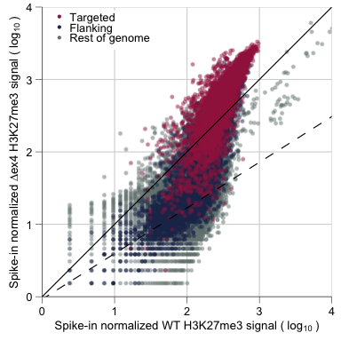

```r
rBins_WT_vs_dex4_Filtered_Targeted
```

Save to pdf.

```r
ggsave(path = pdf_dir_fig5,
       filename = paste0("Fig3C_RASTERIZED_CGI_coloured_WT_vs_Dex4_bins_n", num_fltrd_bins_2.5kb, ".pdf"),
       plot = rBins_WT_vs_dex4_Filtered_Targeted, device = cairo_pdf, units = "cm",
       width = 4.2, height = 4.2)
```

Now do the same but for CSex4 vs WT.

### 3.1.2 Scatter plot CSex4 vs WT

Get linear fit.

```r
intercet_wt_CSex4 <- coef( lm(log_bins25kb_K27me3$CSex4 ~ log_bins25kb_K27me3$WT ) )[1]
slope_wt_CSex4 <- coef( lm(log_bins25kb_K27me3$CSex4 ~ log_bins25kb_K27me3$WT ) )[2]
```

Filter the bins like before. Start by removing the many “rest of the genome” bins

```r
indx_dups_ROTG_wt_CSex4 <- which(duplicated(log_bins25kb_K27me3[log_bins25kb_K27me3$type2 == "Rest of the genome", c("WT", "CSex4")]))
row_names_dups_ROTG <- rownames(log_bins25kb_K27me3[indx_dups_ROTG_wt_CSex4, ])
wt_CSex4_bins <- log_bins25kb_K27me3[!rownames(log_bins25kb_K27me3) %in% row_names_dups_ROTG,]
```

Filter the “PcG targeted CGI” in CSex4 vs WT dataset

```r
indx_dups_PTC_wt_CSex4 <- which(duplicated(wt_CSex4_bins[wt_CSex4_bins$type2 == "PcG targeted CGI", c("WT", "CSex4")] ) )
row_names_dups_PTC <- rownames(wt_CSex4_bins[indx_dups_PTC_wt_CSex4, ])
wt_CSex4_bins <- wt_CSex4_bins[!rownames(wt_CSex4_bins) %in% row_names_dups_PTC,]
```

And the +1 and -1 bins

```r
indx_dups_P1M1_wt_dex4 <- which(duplicated(wt_CSex4_bins[wt_CSex4_bins$type2 %in% c("PcG targeted CGI + 1", "PcG targeted CGI + 1"), c("WT", "CSex4")] ) )
row_names_dups_P1M1 <- rownames(wt_CSex4_bins[indx_dups_P1M1_wt_dex4, ])
wt_CSex4_bins <- wt_CSex4_bins[!rownames(wt_CSex4_bins) %in% row_names_dups_P1M1,]
```

Check number of bins after filtering

```r
num_fltrd_bins_2.5kb <- nrow(wt_CSex4_bins)
message("Number of bins of 2.5kb width to plot: ", num_fltrd_bins_2.5kb)
```

```
Number of bins of 2.5kb width to plot: 16189
```

Basically this filtering removes duplicated points.

```r
ggplot(wt_CSex4_bins) +
  aes(x = WT, y = CSex4, colour = type2) +
  geom_point(size = 0.75, alpha = 0.5, stroke = 0) +
  geom_abline(slope = 1, intercept = 0, linewidth = 0.2) +
  geom_abline(slope = slope_wt_CSex4, intercept = intercet_wt_CSex4,
              linetype = 'dashed', linewidth = 0.2) +
  coord_fixed(ratio = 1, xlim = c(0, 3.5), ylim = c(0, 3.5), clip = 'on' ) +
  scale_x_continuous(expand = expansion(mult = 0, add = c(0, 0.5) ) ) +
  scale_y_continuous(expand = expansion(mult = 0, add = c(0, 0.5) ) ) +
  scale_colour_manual(values = c("PcG targeted CGI" = '#A2234C',
                                 "PcG targeted CGI - 1" = '#203059',
                                 "PcG targeted CGI + 1" = '#203059',
                                 "Rest of the genome" = '#72817F'),
                      breaks = c("PcG targeted CGI",
                                 "PcG targeted CGI + 1",
                                 "Rest of the genome"),
                      labels = c("PcG targeted CGI" = "Targeted",
                                 "PcG targeted CGI + 1" = "Flanking",
                                 "Rest of the genome" = "Rest of genome") ) +
  labs(x = expression("Spike-in normalized WT H3K27me3 signal (" ~ log[10] ~ ")" ),
       y = expression("Spike-in normalized CSex4 H3K27me3 signal (" ~ log[10] ~ ")" ) ) +
  guides(colour = guide_legend(override.aes = list(alpha = 0.99))) +
  scatter_th -> pBins_WT_vs_CSex4_Filtered_Targeted
```

Save to pdf vector.

```r
ggsave(path = pdf_dir_fig5,
       filename = paste0("Fig3B_CGI_coloured_WT_vs_CSex4_bins_n", num_fltrd_bins_2.5kb, ".pdf"),
       plot = pBins_WT_vs_CSex4_Filtered_Targeted, device = cairo_pdf, units = "cm",
       width = 4.2, height = 4.2)
```

Rasterise only the point layer of ggplot

```r
rBins_WT_vs_CSex4_Filtered_Targeted <- rasterize(pBins_WT_vs_CSex4_Filtered_Targeted, layers = 'Point', dpi = 400)
```

Show plot as presented in figure.

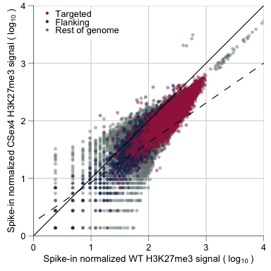

```r
rBins_WT_vs_CSex4_Filtered_Targeted
```

Save to pdf rasterised scatter plot.

```r
ggsave(path = pdf_dir_fig5,
       filename = paste0("Fig3E_RASTERIZED_CGI_coloured_WT_vs_CSex4_bins_n", num_fltrd_bins_2.5kb, ".pdf"),
       plot = rBins_WT_vs_CSex4_Filtered_Targeted, device = cairo_pdf, units = "cm",
       width = 4.2, height = 4.2)
```

### 3.1.3 Boxplot H3K27me3 signal in 2.5kb genomic bins

Display the same H3K27me3 signal in 2.5kb genomic bins as boxplots.

Code below is needed to colour the `ggplot2` facet strip text.

```r
# requires package ggh4x
CGI_coloured_strip <-
  strip_themed(background_x = elem_list_rect(fill = c(
    '#203059', '#A2234C', '#203059', '#72817F'
  )),
  text_x = elem_list_text(colour = c('white')))

strip_CGI_conversion <- c(
  `PcG targeted CGI - 1` = "Flanking up",
  `PcG targeted CGI` = "Targeted CGI",
  `PcG targeted CGI + 1` = "Flanking down",
  `Rest of the genome` = "Rest of genome"
)
```

Plot boxplot for panel 5D.

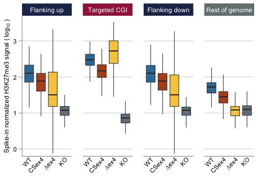

```r
log_bins25kb_K27me3 |>
  as_tibble() |>
  pivot_longer(cols = c("WT", 'CSex4', 'dex4', 'KO'), names_to = 'Sample', values_to = "log10_H3K27me3") |>
  mutate(Sample = factor(Sample, levels = c("WT", 'CSex4', 'dex4', 'KO') ) ) |>
  mutate(type2 = factor(type2, levels = c('PcG targeted CGI - 1', 'PcG targeted CGI', 'PcG targeted CGI + 1', 'Rest of the genome') ) ) |>
  ggplot() +
  aes(x = Sample, y = log10_H3K27me3, fill = Sample) +
  facet_wrap2(~type2, nrow = 1, scales = 'fixed', strip = CGI_coloured_strip,
              labeller = labeller(type2 = strip_CGI_conversion ) ) +
  geom_boxplot(outlier.shape = NA, linewidth = 0.2, show.legend = F) +
  scale_x_discrete(labels = c('dex4' = '∆ex4') ) +
  scale_y_continuous(expand = expansion(mult = 0, add = c(0.2, 0.2) ) ) +
  coord_cartesian(ylim = c(0, 3.5), clip = 'on') +
  scale_fill_manual(values = c('WT' = "#377AA3", 'CSex4' = "#B65120",
                               'dex4' = "#F7CB48",'KO' = "#728189") ) +
  labs(y =  expression("Spike-in normalized H3K27me3 signal (" ~ log[10] ~ ")" ) ) +
  boxplot_th -> pBoxPlot_CGI_quant
pBoxPlot_CGI_quant
```

Save to pdf.

```r
ggsave(path = pdf_dir_fig5,
       filename = paste0("Fig5D_2.5kb_Bins_Boxplot.pdf"),
       plot = pBoxPlot_CGI_quant, device = cairo_pdf, units = "cm",
       width = 7.3, height = 5)
```

## 3.2 H3K27me3 signal at PRC2 targeted (or not) CpG Islands

CGI = CpG islands.

Targted = SUZ12 peak was found to overlap the CGI.

Non-targeted = SUZ12 didn’t bind that CGI.

### 3.2.1 Boxplot spike-in normalised

Import bed files for the boxplots. Here every sample is identified by a number.

```r
# b <- 1
region <- c()
sample <- c()
beds <- list()
for (b in 1:length(bed_paths)) {
  # define region based on letter
  if ( grepl(pattern = "^[1-4]A", x = bed_paths[b] ) ) { region[b] <- "CGI_H3K27me3_genes" }
  else if (grepl(pattern = "^[1-4]B", x = bed_paths[b] ) ) { region[b] <- "CGI_nonPcG_genes" }
  # define sample based on number
  if ( grepl(pattern = "^1", x = bed_paths[b]) ) { sample[b] <- "WT" }
  else if (grepl(pattern = "^2", x = bed_paths[b] ) ) { sample[b] <- "∆ex4" }
  else if (grepl(pattern = "^3", x = bed_paths[b] ) ) { sample[b] <- "KO" }
  else if (grepl(pattern = "^4", x = bed_paths[b] ) ) { sample[b] <- "CSex4" }

  message("Importing sample: ", sample[b], ", region: ", region[b])
  # read in each bed file and annotate it
  read_delim(file = file.path(round17_meta_dir, bed_paths[b]), delim = "\t",
             col_names = c('chr', 'start', 'end', 'min', 'average', 'max', 'sum'),
             show_col_types = FALSE) |>
    mutate(Sample = sample[b], Region = region[b]) |>
    group_by(Sample, Region) |>
    mutate(Numbered_region = n() ) |>
    ungroup() -> beds[[b]]

  names(beds)[b] <- paste0(sample[b], "_", region[b])
}
```

```
Importing sample: WT, region: CGI_H3K27me3_genes
```

```
Importing sample: WT, region: CGI_nonPcG_genes
```

```
Importing sample: ∆ex4, region: CGI_H3K27me3_genes
```

```
Importing sample: ∆ex4, region: CGI_nonPcG_genes
```

```
Importing sample: KO, region: CGI_H3K27me3_genes
```

```
Importing sample: KO, region: CGI_nonPcG_genes
```

```
Importing sample: CSex4, region: CGI_H3K27me3_genes
```

```
Importing sample: CSex4, region: CGI_nonPcG_genes
```

Merge list of dataframes (bed files) into one.

```r
all_beds <- do.call('rbind', beds) |>
  mutate(Sample = factor(Sample, levels = c("WT", "CSex4", "∆ex4", "KO")) ) |>
  mutate(Pretty_Region = case_when(Region == "CGI_H3K27me3_genes" ~ "PRC2 targeted CGI",
                                   Region == "CGI_nonPcG_genes" ~ "Other CGI") ) |>
  mutate(Pretty_Region = paste0(Pretty_Region, " (n = ", Numbered_region, ")" ) ) |>
  mutate(Pretty_Region = factor(Pretty_Region,
                                levels = c("PRC2 targeted CGI (n = 2665)",
                                           "Other CGI (n = 9999)") ) )
```

Set colours for facets strip text

```r
Metaplot_coloured_strip <- strip_themed(background_x = elem_list_rect(fill = c('#A2234C', '#003e1f') ),
                                   text_x = elem_list_text(colour = c('white') ) )

strip_CGI_conversion <- c(
  `PRC2 targeted CGI (n = 2665)` = "SUZ12 Targeted CGI (n = 2665)",
  `Other CGI (n = 9999)` = "Non-targeted CGI (n = 9999)"
)
```

Plot H3K27me3 signal in the CGI targeted regions used for the meta genes later on as a boxplot.

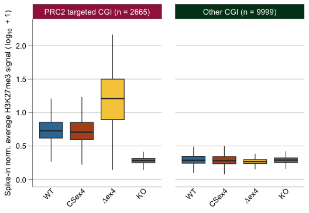

```r
ggplot(all_beds) +
  aes(x = Sample, y = log(average + 1, base = 10), fill = Sample) +
  facet_wrap2( ~Pretty_Region, strip = Metaplot_coloured_strip,
              labeller = labeller(type = strip_CGI_conversion) ) +
  geom_boxplot(outlier.shape = NA, show.legend = F, linewidth = 0.2) +
  scale_fill_manual(values = c('WT' = "#377AA3", 'CSex4' = "#B65120",
                               '∆ex4' = "#F7CB48",'KO' = "#728189") ) +
  labs(y = expression("Spike-in norm. average H3K27me3 signal (" ~ log[10] ~ " + 1)" ) ) +
  boxplot_th -> p_metagenes_regions_signal_boxplot
p_metagenes_regions_signal_boxplot
```

Save to pdf.

```r
ggsave(path = pdf_dir_fig5,
       filename = paste0("Metagenes_regions_H3K27me3_signal_Boxplot.pdf"),
       plot = p_metagenes_regions_signal_boxplot, device = cairo_pdf, units = "cm",
       width = 7.3, height = 5)
```

### 3.2.2 Metagene profiles spike-in normalised

Import profiles stored in text files.

First import the files Ivano made for the targeted CGI.

```r
CGI_targeted_K27me3_WT <- read_delim(
  file = file.path(CGI_Dir, "14_MetaCGIplots/7A_GENEplot_5000/GENEprofile_7A_5000.txt"),
  delim = '\t', show_col_types = FALSE ) |>
  setNames(c("MetaPosition", "K27me3_signal") ) |>
  mutate(type = "PRC2 targeted CGI", Sample = "WT")

CGI_targeted_K27me3_dex4 <- read_delim(
  file = file.path(CGI_Dir, "14_MetaCGIplots/8A_GENEplot_5000/GENEprofile_8A_5000.txt"),
  delim = '\t', show_col_types = FALSE ) |>
  setNames(c("MetaPosition", "K27me3_signal") ) |>
  mutate(type = "PRC2 targeted CGI", Sample = "dex4")

CGI_targeted_K27me3_KO <- read_delim(
  file = file.path(CGI_Dir, "14_MetaCGIplots/9A_GENEplot_5000/GENEprofile_9A_5000.txt"),
  delim = '\t', show_col_types = FALSE ) |>
  setNames(c("MetaPosition", "K27me3_signal") ) |>
  mutate(type = "PRC2 targeted CGI", Sample = "KO")

CGI_targeted_K27me3_CSex4 <- read_delim(
  file = file.path(CGI_Dir, "16_MetaCGIplotsEx4100/E3_GENEplot_5000/GENEprofile_E3_5000.txt"),
  delim = '\t', show_col_types = FALSE ) |>
  setNames(c("MetaPosition", "K27me3_signal") ) |>
  mutate(type = "PRC2 targeted CGI", Sample = "CSex4")

CGI_targeted_K27me3 <- rbind(CGI_targeted_K27me3_WT, CGI_targeted_K27me3_dex4, CGI_targeted_K27me3_KO, CGI_targeted_K27me3_CSex4) |>
  as_tibble()
```

Then import the non-targeted CGI.

```r
CGI_other_K27me3_WT <- read_delim(
  file = file.path(CGI_Dir, "14_MetaCGIplots/7B_GENEplot_5000/GENEprofile_7B_5000.txt"),
  delim = '\t', show_col_types = FALSE ) |>
  setNames(c("MetaPosition", "K27me3_signal") ) |>
  mutate(type = "Other CGI", Sample = "WT")

CGI_other_K27me3_dex4 <- read_delim(
  file = file.path(CGI_Dir, "14_MetaCGIplots/8B_GENEplot_5000/GENEprofile_8B_5000.txt"),
  delim = '\t', show_col_types = FALSE ) |>
  setNames(c("MetaPosition", "K27me3_signal") ) |>
  mutate(type = "Other CGI", Sample = "dex4")

CGI_other_K27me3_KO <- read_delim(
  file = file.path(CGI_Dir, "14_MetaCGIplots/9B_GENEplot_5000/GENEprofile_9B_5000.txt"),
  delim = '\t', show_col_types = FALSE ) |>
  setNames(c("MetaPosition", "K27me3_signal") ) |>
  mutate(type = "Other CGI", Sample = "KO")

CGI_other_K27me3_CSex4 <- read_delim(
  file = file.path(CGI_Dir,"16_MetaCGIplotsEx4100/E1_GENEplot_5000/GENEprofile_E1_5000.txt"),
  delim = '\t', show_col_types = FALSE ) |>
  setNames(c("MetaPosition", "K27me3_signal") ) |>
  mutate(type = "Other CGI", Sample = "CSex4")

CGI_other_K27me3 <- rbind(CGI_other_K27me3_WT, CGI_other_K27me3_dex4, CGI_other_K27me3_KO, CGI_other_K27me3_CSex4) |>
  as_tibble()
```

Combine data and reshape it for plotting.

```r
Meta_K27me3 <- rbind(CGI_targeted_K27me3, CGI_other_K27me3) |>
  mutate(MetaPosition = MetaPosition - 5000) |>
  mutate(type = factor(type, levels = c("PRC2 targeted CGI", "Other CGI") )) |>
  group_by(Sample, type) |>
  arrange(MetaPosition) |>
  ungroup() |>
  mutate(Sample = factor(Sample, levels = c('WT', 'CSex4', 'dex4', 'KO') ) ) |>
  mutate(MetaPosition = MetaPosition / 1000)  # turn bases in kilo-bases
```

Rename strip for the figure

```r
strip_CGI_conversion <- c(
  `PRC2 targeted CGI` = "SUZ12 targeted CGI",
  `Other CGI` = "Non-targeted CGI"
)
```

Since the data contains every single nucleotide signal, I use only 1/4 of the data to plot as this does not affect the trend, but makes the pdf file easier to work with. This is done by using `sample_frac(size = 0.25)`.

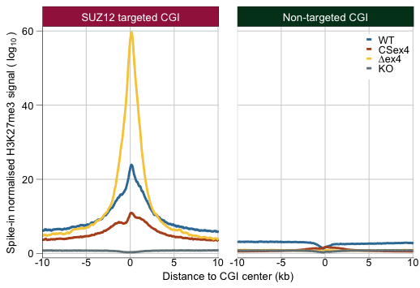

```r
Meta_K27me3 |>
  sample_frac(size = 0.25) |>
ggplot() +
  aes(x = MetaPosition, y = K27me3_signal, colour = Sample) +
  facet_wrap2( ~type, strip = Metaplot_coloured_strip,
              labeller = labeller(type = strip_CGI_conversion) ) +
  geom_line(linewidth = 0.5) +
  scale_x_continuous(expand = expansion(mult = 0, add = c(0, 0.1) ),
                     breaks = c(-10, -5, 0, 5, 10) ) +
  scale_y_continuous(expand = expansion(mult = 0.025, add = 0 ) ) +
  scale_colour_manual(values = c('WT' = "#377AA3", 'CSex4' = "#B65120",
                                 'dex4' = "#F7CB48",'KO' = "#728189"),
                      labels = c('dex4' = '∆ex4') ) +
  labs(x = 'Distance to CGI center (kb)',
       y = expression("Spike-in normalised H3K27me3 signal (" ~ log[10] ~ ")" )) +
  profile_th -> pMetaPlot_CGI
pMetaPlot_CGI
```

Save to pdf.

```r
ggsave(path = pdf_dir_fig5,
       filename = paste0("Fig3E_Targeted_CGI_Metagene_Profiles.pdf"),
       plot = pMetaPlot_CGI, device = cairo_pdf, units = "cm",
       width = 7.3, height = 4.9)
```

## 3.3 MTF2 signal at PRC2 targeted (or not) CpG Islands

MTF2 is a component of the PRC2.1 complex.

Metagene profile spike-in normalised.

Import the files Enrique made for the targeted CGI for the MTF2 ChIP-seq.

```r
trgtd_MTF2_WT1 <- read_prfl(path_dir = round21_meta_dir,
                                   txt_name = "M1A_GENEplot_5000/GENEprofile_M1A_5000.txt",
                                   epitope = "MTF2", geneset_type = "PRC2 targeted CGI",
                                   sample_name = "WT1")

trgtd_MTF2_WT2 <- read_prfl(path_dir = round21_meta_dir,
                                   txt_name = "M2A_GENEplot_5000/GENEprofile_M2A_5000.txt",
                                   epitope = "MTF2", geneset_type = "PRC2 targeted CGI",
                                   sample_name = "WT2")

trgtd_MTF2_CSex4a <- read_prfl(path_dir = round21_meta_dir,
                               txt_name = "M3A_GENEplot_5000/GENEprofile_M3A_5000.txt",
                               epitope = "MTF2", geneset_type = "PRC2 targeted CGI",
                               sample_name = "CSex4a")

trgtd_MTF2_CSex4b <- read_prfl(path_dir = round21_meta_dir,
                               txt_name = "M4A_GENEplot_5000/GENEprofile_M4A_5000.txt",
                               epitope = "MTF2", geneset_type = "PRC2 targeted CGI",
                               sample_name = "CSex4b")

trgtd_MTF2_dex4a <- read_prfl(path_dir = round21_meta_dir,
                              txt_name = "M5A_GENEplot_5000/GENEprofile_M5A_5000.txt",
                              epitope = "MTF2", geneset_type = "PRC2 targeted CGI",
                              sample_name = "∆ex4a")

trgtd_MTF2_dex4b <- read_prfl(path_dir = round21_meta_dir,
                              txt_name = "M6A_GENEplot_5000/GENEprofile_M6A_5000.txt",
                              epitope = "MTF2", geneset_type = "PRC2 targeted CGI",
                              sample_name = "∆ex4b")

CGI_targeted_MTF2 <- rbind(trgtd_MTF2_WT1, trgtd_MTF2_WT2,
                           trgtd_MTF2_CSex4a, trgtd_MTF2_CSex4b,
                           trgtd_MTF2_dex4a, trgtd_MTF2_dex4b) |>
  as_tibble()
```

Import MTF2 signal at non-targeted CGI.

```r
nontrgtd_MTF2_WT1 <- read_prfl(path_dir = round21_meta_dir,
                                   txt_name = "M1B_GENEplot_5000/GENEprofile_M1B_5000.txt",
                                   epitope = "MTF2", geneset_type = "Other CGI",
                                   sample_name = "WT1")

nontrgtd_MTF2_WT2 <- read_prfl(path_dir = round21_meta_dir,
                                   txt_name = "M2B_GENEplot_5000/GENEprofile_M2B_5000.txt",
                                   epitope = "MTF2", geneset_type = "Other CGI",
                                   sample_name = "WT2")

nontrgtd_MTF2_CSex4a <- read_prfl(path_dir = round21_meta_dir,
                               txt_name = "M3B_GENEplot_5000/GENEprofile_M3B_5000.txt",
                               epitope = "MTF2", geneset_type = "Other CGI",
                               sample_name = "CSex4a")

nontrgtd_MTF2_CSex4b <- read_prfl(path_dir = round21_meta_dir,
                               txt_name = "M4B_GENEplot_5000/GENEprofile_M4B_5000.txt",
                               epitope = "MTF2", geneset_type = "Other CGI",
                               sample_name = "CSex4b")

nontrgtd_MTF2_dex4a <- read_prfl(path_dir = round21_meta_dir,
                              txt_name = "M5B_GENEplot_5000/GENEprofile_M5B_5000.txt",
                              epitope = "MTF2", geneset_type = "Other CGI",
                              sample_name = "∆ex4a")

nontrgtd_MTF2_dex4b <- read_prfl(path_dir = round21_meta_dir,
                              txt_name = "M6B_GENEplot_5000/GENEprofile_M6B_5000.txt",
                              epitope = "MTF2", geneset_type = "Other CGI",
                              sample_name = "∆ex4b")

CGI_other_MTF2 <- rbind(nontrgtd_MTF2_WT1, nontrgtd_MTF2_WT2,
                        nontrgtd_MTF2_CSex4a, nontrgtd_MTF2_CSex4b,
                        nontrgtd_MTF2_dex4a, nontrgtd_MTF2_dex4b) |>
  as_tibble()
```

Combine data and reshape it for plotting. Since the data contains every single nucleotide signal, I use only 1/4 of the data to plot as this does not affect the trend, but makes the pdf file easier to work with. This is done by using `sample_frac(size = 0.25)`.

```r
Meta_MTF2 <- rbind(CGI_targeted_MTF2, CGI_other_MTF2) |>
  mutate(MetaPosition = MetaPosition - 5000) |>
  mutate(Genotype = str_remove(pattern = "[a1-z9]$", string = Sample)) |>
  mutate(type = factor(type, levels = c("PRC2 targeted CGI", "Other CGI") )) |>
  group_by(Genotype, type, MetaPosition) |>
  mutate(Average_Signal = mean(MTF2_signal, na.rm = T) )|>
  arrange(MetaPosition) |>
  ungroup() |>
  mutate(Genotype = factor(Genotype, levels = c('WT', 'CSex4', '∆ex4') ) ) |>
  mutate(Sample = factor(Sample, levels = c('WT1', 'WT2', 'CSex4a', 'CSex4b', '∆ex4a', '∆ex4b') ) ) |>
  mutate(MetaPosition = MetaPosition / 1000) |> # turn bases in kilo-bases
# subset a small a fraction of the total.
  select(MetaPosition, type, Genotype, Average_Signal) |>
  unique() |> sample_frac(size = 0.25)
```

Set colour palettes

```r
samples_palette <- c('WT1' = "#377AA3", 'WT2' = "#377AA3",
                     'CSex4a' = "#B65120", 'CSex4b' = "#B65120",
                     '∆ex4a' = "#F7CB48", '∆ex4b' = "#F7CB48")

genotype_palette <- c('WT' = "#377AA3", 'CSex4' = "#B65120", '∆ex4' = "#F7CB48")
```

Plot MTF2 profile

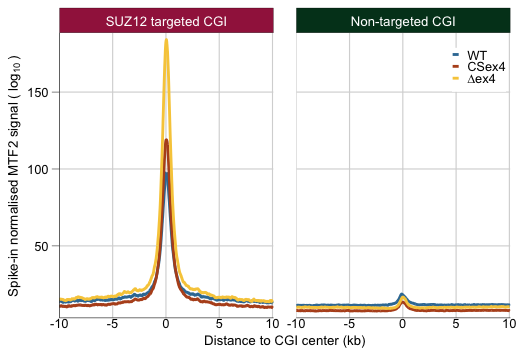

```r
ggplot(Meta_MTF2) +
  aes(x = MetaPosition, y = Average_Signal, colour = Genotype) +
  facet_wrap2( ~type, strip = Metaplot_coloured_strip,
              labeller = labeller(type = strip_CGI_conversion) ) +
  geom_line(linewidth = 0.5) +
  scale_x_continuous(expand = expansion(mult = 0, add = c(0, 0.1) ),
                     breaks = c(-10, -5, 0, 5, 10) ) +
  scale_y_continuous(expand = expansion(mult = 0.025, add = 0 ) ) +
  scale_colour_manual(values = genotype_palette ) +
  labs(x = 'Distance to CGI center (kb)',
       y = expression("Spike-in normalised MTF2 signal (" ~ log[10] ~ ")" )) +
  profile_th -> pMetaPlot_CGI_MTF2
pMetaPlot_CGI_MTF2
```

Save to pdf.

```r
ggsave(path = pdf_dir_fig5,
       filename = paste0("Fig5XYZ_MTF2_Targeted_CGI_Metagene_Profiles.pdf"),
       plot = pMetaPlot_CGI_MTF2, device = cairo_pdf, units = "cm",
       width = 7.3, height = 4.9)
```

## 3.4 JARID2 signal at PRC2 targeted (or not) CpG Islands

Metagene profile spike-in normalised.

Import JARID2 targeted CGI signal

```r
trgtd_JARID2_WT1 <- read_prfl(path_dir = round21_meta_dir,
                                 txt_name = "J1A_GENEplot_5000/GENEprofile_J1A_5000.txt",
                                 epitope = "JARID2", geneset_type = "PRC2 targeted CGI",
                                 sample_name = "WT1")

trgtd_JARID2_WT2 <- read_prfl(path_dir = round21_meta_dir,
                                   txt_name = "J2A_GENEplot_5000/GENEprofile_J2A_5000.txt",
                                   epitope = "JARID2", geneset_type = "PRC2 targeted CGI",
                                   sample_name = "WT2")

trgtd_JARID2_CSex4a <- read_prfl(path_dir = round21_meta_dir,
                               txt_name = "J3A_GENEplot_5000/GENEprofile_J3A_5000.txt",
                               epitope = "JARID2", geneset_type = "PRC2 targeted CGI",
                               sample_name = "CSex4a")

trgtd_JARID2_CSex4b <- read_prfl(path_dir = round21_meta_dir,
                               txt_name = "J4A_GENEplot_5000/GENEprofile_J4A_5000.txt",
                               epitope = "JARID2", geneset_type = "PRC2 targeted CGI",
                               sample_name = "CSex4b")

trgtd_JARID2_dex4a <- read_prfl(path_dir = round21_meta_dir,
                              txt_name = "J5A_GENEplot_5000/GENEprofile_J5A_5000.txt",
                              epitope = "JARID2", geneset_type = "PRC2 targeted CGI",
                              sample_name = "∆ex4a")

trgtd_JARID2_dex4b <- read_prfl(path_dir = round21_meta_dir,
                              txt_name = "J6A_GENEplot_5000/GENEprofile_J6A_5000.txt",
                              epitope = "JARID2", geneset_type = "PRC2 targeted CGI",
                              sample_name = "∆ex4b")

CGI_targeted_JARID2 <- rbind(trgtd_JARID2_WT1, trgtd_JARID2_WT2,
                             trgtd_JARID2_CSex4a, trgtd_JARID2_CSex4b,
                             trgtd_JARID2_dex4a, trgtd_JARID2_dex4b) |>
  as_tibble()
```

Import JARID2 signal at non-targeted CGI.

```r
nontrgtd_JARID2_WT1 <- read_prfl(path_dir = round21_meta_dir,
                                   txt_name = "J1B_GENEplot_5000/GENEprofile_J1B_5000.txt",
                                   epitope = "JARID2", geneset_type = "Other CGI",
                                   sample_name = "WT1")

nontrgtd_JARID2_WT2 <- read_prfl(path_dir = round21_meta_dir,
                                   txt_name = "J2B_GENEplot_5000/GENEprofile_J2B_5000.txt",
                                   epitope = "JARID2", geneset_type = "Other CGI",
                                   sample_name = "WT2")

nontrgtd_JARID2_CSex4a <- read_prfl(path_dir = round21_meta_dir,
                               txt_name = "J3B_GENEplot_5000/GENEprofile_J3B_5000.txt",
                               epitope = "JARID2", geneset_type = "Other CGI",
                               sample_name = "CSex4a")

nontrgtd_JARID2_CSex4b <- read_prfl(path_dir = round21_meta_dir,
                               txt_name = "J4B_GENEplot_5000/GENEprofile_J4B_5000.txt",
                               epitope = "JARID2", geneset_type = "Other CGI",
                               sample_name = "CSex4b")

nontrgtd_JARID2_dex4a <- read_prfl(path_dir = round21_meta_dir,
                              txt_name = "J5B_GENEplot_5000/GENEprofile_J5B_5000.txt",
                              epitope = "JARID2", geneset_type = "Other CGI",
                              sample_name = "∆ex4a")

nontrgtd_JARID2_dex4b <- read_prfl(path_dir = round21_meta_dir,
                              txt_name = "J6B_GENEplot_5000/GENEprofile_J6B_5000.txt",
                              epitope = "JARID2", geneset_type = "Other CGI",
                              sample_name = "∆ex4b")

CGI_other_JARID2 <- rbind(nontrgtd_JARID2_WT1, nontrgtd_JARID2_WT2,
                        nontrgtd_JARID2_CSex4a, nontrgtd_JARID2_CSex4b,
                        nontrgtd_JARID2_dex4a, nontrgtd_JARID2_dex4b) |>
  as_tibble()
```

Combine data and reshape it for plotting.

```r
Meta_JARID2 <- rbind(CGI_targeted_JARID2, CGI_other_JARID2) |>
  mutate(MetaPosition = MetaPosition - 5000) |>
  mutate(Genotype = str_remove(pattern = "[a1-z9]$", string = Sample)) |>
  mutate(type = factor(type, levels = c("PRC2 targeted CGI", "Other CGI") )) |>
  group_by(Genotype, type, MetaPosition) |>
  mutate(Average_Signal = mean(JARID2_signal, na.rm = T) )|>
  arrange(MetaPosition) |>
  ungroup() |>
  mutate(Genotype = factor(Genotype, levels = c('WT', 'CSex4', '∆ex4') ) ) |>
  mutate(Sample = factor(Sample, levels = c('WT1', 'WT2', 'CSex4a', 'CSex4b', '∆ex4a', '∆ex4b') ) ) |>
  mutate(MetaPosition = MetaPosition / 1000) |> # turn bases in kilo-bases
# subset a small a fraction of the total.
  select(MetaPosition, type, Genotype, Average_Signal) |>
  unique() |> sample_frac(size = 0.25)
```

Plot JARID2 profile

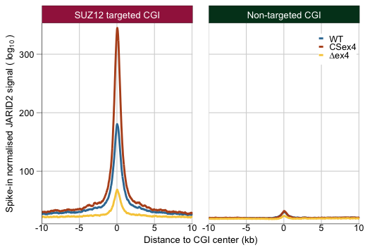

```r
ggplot(Meta_JARID2) +
  aes(x = MetaPosition, y = Average_Signal, colour = Genotype) +
  facet_wrap2( ~type, strip = Metaplot_coloured_strip,
              labeller = labeller(type = strip_CGI_conversion) ) +
  geom_line(linewidth = 0.5) +
  scale_x_continuous(expand = expansion(mult = 0, add = c(0, 0.1) ),
                     breaks = c(-10, -5, 0, 5, 10) ) +
  scale_y_continuous(expand = expansion(mult = 0.025, add = 0 ) ) +
  scale_colour_manual(values = genotype_palette ) +
  labs(x = 'Distance to CGI center (kb)',
       y = expression("Spike-in normalised JARID2 signal (" ~ log[10] ~ ")" )) +
  profile_th -> pMetaPlot_CGI_JARID2
pMetaPlot_CGI_JARID2
```

Save to pdf.

```r
ggsave(path = pdf_dir_fig5,
       filename = paste0("Fig5XYZ_JARID2_Targeted_CGI_Metagene_Profiles.pdf"),
       plot = pMetaPlot_CGI_JARID2, device = cairo_pdf, units = "cm",
       width = 7.3, height = 4.9)
```

## 3.5 AEBP2 signal at PRC2 targeted (or not) CpG Islands

### 3.5.1 Metagene profile not spike-in normalised

## 3.6 RING1B signal at PRC2 targeted (or not) CpG Islands

### 3.6.1 Metagene profile not spike-in normalised

## 3.7 H2Aub1 signal at PRC2 targeted (or not) CpG Islands

### 3.7.1 Metagene profile not spike-in normalised

# 4 Supplementary Figure Panels

## 4.1 Venn diagram SUZ12 peaks

Needed to be better shown for reviewer #1 major point #7

## 4.2 ChIP-qPCR controls

## 4.3 Individual replicates metagene profiles without spike-in normalisation

## 4.4 Spie chart distribution H3K27me3 in ∆ex4 ESCs.

## 4.5 Amniota Testes H3K27me3 re-analysis

Brief overview of the analysis using `bwa` for mapping the reads, `macs2` to call the peaks, and `deeptools` to make bigwigs from bam files and calculate a metagene profile the matrix at the peaks.

Fastq files alignment:

```bash
bwa mem -t $Num_Processes -M -Y -K 100000000 \
  -R ${read_group_header} -T 30 \
  -o ${SAM_DIR}/${full_sample_name}.sam ${BWA_SPECIES_INDX_DIR}/${SPECIES_GENOME_ASSEMBLY}_gDNA_bwtsw_indx ${READ_INPUT}
```

Sam files convertion to bam files, with filtering of non primary alignments.

```bash
samtools view -@ $Num_Processes --with-header --exclude-flags 0x0100 ${file_name} | \
  samtools sort -@ $Num_Processes --output-fmt BAM --verbosity 4 -m 24G -l 1 \
    -T ${sample_target_id} --output-fmt BAM -o ${full_sample_name}_pa_srtd.bam -
```

Mark duplicated reads

```bash
picard MarkDuplicates \
                I=${file} \
                O=${MRKD_DUPS_BAM} \
                M=${MTRCS_FILE} \
                ASSUME_SORTED=true \
                DUPLICATE_SCORING_STRATEGY=SUM_OF_BASE_QUALITIES \
                TAGGING_POLICY=All \
                REMOVE_DUPLICATES=false \
                VALIDATION_STRINGENCY=LENIENT \
                QUIET=false \
                COMPRESSION_LEVEL=9 \
                VERBOSITY=INFO
```

and removing the duplicated reads

```
samtools view -@ $Num_Processes --with-header \
  --exclude-flags 0x004 --exclude-flags 0x0400 \
  -b -o ${OUTPUT_BAM_FILE} ${file}
```

```bash
samtools merge -o ${INPUT_BAM_DIR}/${SPECIES_GENOME_SUFFIX}_${CELL_TYPE}_${TARGET}_mrgd_${bam_suffix}.bam ${bam_files}
```

For both the individual reps and the merged replicates.

```bash
bamCoverage --bam ${bam_files} \
            -o ${MRGD_BW_OUT_SAMPLE} \
            --outFileFormat bigwig \
            --binSize ${bin_size} \
            --normalizeUsing ${norm_method} \
            --effectiveGenomeSize ${EFF_GENOME_SIZE} \
            --extendReads ${gDNA_fragment_size} \
            --ignoreForNormalization chrX chrM \
            --verbose \
            --numberOfProcessors ${Num_Processes}
```

Peak calling:

Effective genome size (how much of the genome is mappable) was calculated using `faCount` method (total (A+C+G+T) nt - N nt).

- hg38= 2913022398
- macmul10= 2936876161
- mm10= 2652783500
- bostau9= 2715825630
- mondom5= 3501660299
- galgal6= 1055580959

*q*-value threshold was very strong at `0.000001`. Minimum fragment size: `20`. In addition `MIN_PEAK_LEN == "NULL" && MAX_GAP_BETWEEN_PEAKS == "NULL"` so that `PEAK_ARGS=""`.

```bash
macs2 callpeak --treatment ${TREAT_FILE_PS} --control ${CNTRL_FILE_PS} \
  --format BAM --outdir ${OUT_DIR} --gsize ${EFF_GENOME_SIZE} \
  --qvalue ${QVAL_THRSHLD} --seed 16 --verbose 1 \
  --slocal 1000 --llocal 10000 --scale-to small ${PEAK_ARGS}
  --d-min ${MIN_D_FRAG} --cutoff-analysis \
  --call-summits --name "${treatment_file_name}"
```

From UCSC we downloaded the CGI coordinates and the peaks summits were intersected with the CGI. Here below I past the human command as an example.

```bash
bedtools intersect -a ../../peak/macs2/Amniota_Testes/hg38_dups_rmvd/q0.000001_minDEFAULT_gapDEFAULT/HomSap_PS_K27me3/HomSap_PS_K27me3_summits.bed -b CGI/CpG_hg38_n27949.bed | grep "^chr" > Peaks_intersect_CGI_hg38_n26997.bed
```

The matrix was generated with:

```bash
computeMatrix reference-point -S ${mergd_reps.bigwig} -R ${Peaks_intersect_CGI.bed} \
    --outFileName ${MAT_OUT_SAMPLE} --outFileNameMatrix ${TAB_OUT_SAMPLE} \
    --numberOfProcessors $Num_Processes --beforeRegionStartLength 7500 \
    --afterRegionStartLength 7500 \
    --referencePoint center --binSize 50 \
    --missingDataAsZero --smartLabels --sortRegions "descend"
```

Now I list the paths to all the matrixes for each assembly.

```r
assembly_dir <- list.files(mat_dir, pattern = '_Summits_in_CGIs_mrgd')

bed_name <- 'Summits_in_CGIs'

lapply(assembly_dir,  function(x){
  list.files(path = file.path(mat_dir, x),
             pattern = paste0("PS_K27me3_", bed_name, "_UP7500_DW7500_bs50.tab"), full.names = T)
}) |> unlist() -> tab_path_list
```

For plotting I import the matrix generated by `computeMatrix` in R.

```r
list_df <- list()
for (a in 1:length(assembly_dir)) {

  tab_df <- read_delim(file = tab_path_list[a], skip = 3,
                       delim = "\t", escape_double = FALSE, show_col_types = F,
                       col_names = FALSE, comment = "#", trim_ws = TRUE, skip_empty_rows = T)

  tab_df |>
    colMeans() |>
    as_tibble() |>
    setNames('H3K27me3_signal') |>
    rownames_to_column("bin") |>
    mutate(bin = as.integer(bin) ) |>
    mutate(Species = gsub(paste0('_', bed_name, '_mrgd'), '', assembly_dir[a] ),
           .before = bin ) -> tidy_bins

  list_df[[a]] <- tidy_bins
}

df_species <- do.call('rbind', list_df)
```

Reshape the data and prepare it for plotting. Note: the `[,1]` after `scale()` is not really necessary but gives better colnames. To scale from zero to 1, I use my simple function `scale01`.

```r
df_species |>
  group_by(Species) |>
  mutate(scaled_H3K27me3_signal = scale(H3K27me3_signal)[,1],
         scaled01_H3K27me3_signal = scale01(H3K27me3_signal) ) |>
  pivot_longer(ends_with("H3K27me3_signal"), names_to = 'Scaling_Type', values_to = 'Signal') |>
  mutate(Species = case_when( Species == 'GalGal' ~ 'Chicken',
                              Species == 'HomSap' ~ 'Human',
                              Species == 'MonDom' ~ 'Opossum',
                              Species == 'MusMus' ~ 'Mouse',
                              ) ) |>
  mutate(Species = factor(Species, levels = c('Human', 'Mouse', 'Opossum', 'Chicken'))) |>
  ungroup() -> tidy_df_species
```

Rename strip for the figure

```r
Metaplot_scaling_strip <- strip_themed(
  background_x = elem_list_rect(fill = c('#f05b43', '#f7dea3', '#748f46' ) ),
  text_x = elem_list_text(colour = c('white', 'black', 'white') )
  )

strip_scaling_conversion <- c(
  `H3K27me3_signal` = "Raw H3K27me3 signal",
  `scaled_H3K27me3_signal` = "Scaled H3K27me3 signal",
  `scaled01_H3K27me3_signal` = "0 - 1 scaled H3K27me3 signal"
)
```

Plot all the metagene profiles with different scaling methods.

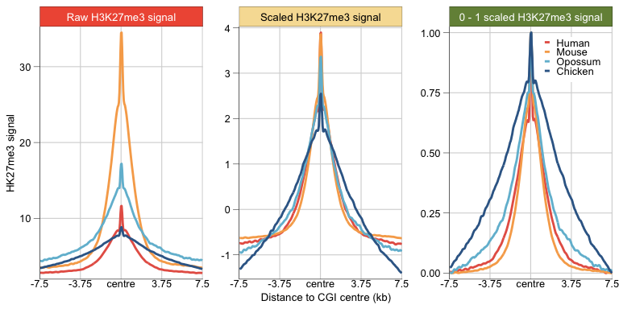

```r
ggplot(tidy_df_species) +
    aes(x = bin, y = Signal, colour = Species) +
    facet_wrap2( ~ Scaling_Type, nrow = 1, scales = 'free_y', strip = Metaplot_scaling_strip,
              labeller = labeller(Scaling_Type = strip_scaling_conversion ) ) +
    geom_path(linewidth = 0.5)+
    scale_colour_manual(values = c('Human' = "#e76254", 'Mouse' = "#f7aa58",
                                   'Opossum' = "#72bcd5", 'Chicken' = "#376795")) +
    scale_x_continuous(breaks = c(0, 75, 150, 225, 300),
                       labels = c('-7.5', '-3.75', 'centre', '3.75', '7.5'),
                       expand = expansion(mult = 0, add = 1) ) +
    scale_y_continuous(expand = expansion(mult = 0.025, add = 0 ) ) +
    labs(x = "Distance to CGI centre (kb)", y = 'HK27me3 signal') +
    profile_th -> p_profile_scaling_Amniotes
p_profile_scaling_Amniotes
```

Save to pdf

```r
ggsave(filename = 'Lesch_4Species_H3K27me3_Scaling_Metagene_Profile.pdf',
       path = pdf_dir_fig5, plot = p_profile_scaling_Amniotes,
       device = cairo_pdf, units = 'cm',  width = 10, height = 5)
```

Change strip name for the supplementary figure. These are “targeted CGI” because they contain H3K27me3 signal, but there’s no direct evidence of PRC2 binding there.

```r
Metaplot_scaling_strip <- strip_themed(
  background_x = elem_list_rect(fill = c('#f05b43') ),
  text_x = elem_list_text(colour = c('white', 'black', 'white') )
  )

strip_scaling_conversion <- c(
  `scaled01_H3K27me3_signal` = "Targeted CGI"
)
```

Plot supplementary figure 5 XYZ.

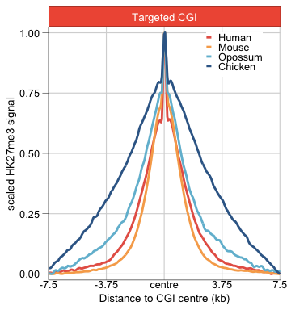

```r
subset(tidy_df_species, Scaling_Type == 'scaled01_H3K27me3_signal') |>
ggplot() +
    aes(x = bin, y = Signal, colour = Species) +
    facet_wrap2( ~ Scaling_Type, nrow = 1, scales = 'free_y', strip = Metaplot_scaling_strip,
              labeller = labeller(Scaling_Type = strip_scaling_conversion ) ) +
    geom_path(linewidth = 0.5)+
    scale_colour_manual(values = c('Human' = "#e76254", 'Mouse' = "#f7aa58",
                                   'Opossum' = "#72bcd5", 'Chicken' = "#376795")) +
    scale_x_continuous(breaks = c(0, 75, 150, 225, 300),
                       labels = c('-7.5', '-3.75', 'centre', '3.75', '7.5'),
                       expand = expansion(mult = 0, add = 1) ) +
    scale_y_continuous(expand = expansion(mult = 0.025, add = 0 ) ) +
    labs(x = "Distance to CGI centre (kb)", y = 'scaled HK27me3 signal') +
    profile_th +
    theme(legend.position = c(0.8, 0.89) ) -> p_profile_01scaled_Amniotes
p_profile_01scaled_Amniotes
```

Save to pdf.

```r
ggsave(filename = 'FigS5XYZ_4Species_H3K27me3_Metagene_Profile.pdf',
       path = pdf_dir_fig5, plot = p_profile_01scaled_Amniotes,
       device = cairo_pdf, units = 'cm', width = 4, height = 5)
```

I think I should also have made a set of bed files where there’s no intersection of CGI and H3K27me3 to be used as “non-targeted CGI”.

End of analysis.